# Immune cell data preprocessing

Scott Campit

# Summary

This notebook performs data preprocessing on the initial seurat object.

# 1. Load libraries

```r
library(mgcv)
library(splines)
library(Seurat)
library(tidyverse)
library(viridis)
library(matrixStats)
library(UpSetR)
library(reshape2)
library(ggplot2)
library(phateR)
library(reticulate)
#install.packages('readxl')
library(readxl)

install.packages('sctransform')
```

```
Error in install.packages : Updating loaded packages
```

```r
library(sctransform)
```

# 2. Load the data

This code block does the following with the lung dataset:

Note that there were cell-type annotations in the meta data. I used those for visualization.

```r
rm(list=ls())
#load("C:/Users/scott/Data/scRNASeq/shea/lung.robj", verbose=TRUE)
load("D:/Data/scRNASeq/shea/lung.robj", verbose=TRUE)
```

```
Loading objects:
  lung
```

```r
orig.ident = lung@active.ident
```

# Analyze the data distribution

We’ll analyze the underlying data distribution. Additionally, we’ll perform the following data preprocessing steps: * Remove genes with a library size less than 250 * Remove cells with no gene expression * Remove cells that are not expressed

```r
data_preprocessing = function(seurat_obj,
                              min_library_size=250,
                              min_total_expr=1,
                              min_no_of_cells=5){

  seurat_obj = subset(seurat_obj, subset = nFeature_RNA > min_library_size &
                                           nCount_RNA > min_library_size)

}
```

# 3. Visualize some QA/QC plots

Let’s now visualize some global metrics of our data.

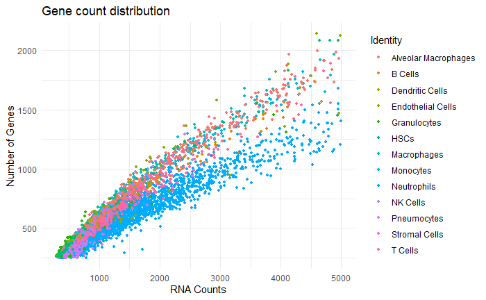

```r
FeatureScatter(object=lung,
               feature1="nCount_RNA",
               feature2="nFeature_RNA") +
  theme_minimal() +
  labs(x="RNA Counts",
       y="Number of Genes",
       title="Gene count distribution")
```

# 4. Detecting Variable Genes

```r
lung = FindVariableFeatures(object=lung,
                            mean.function=ExpMean,
                            dispersion.function=LogVMR,
                            selection.method='vst',
                            x.low.cutoff=-Inf,
                            x.high.cutoff=Inf,
                            y.cutoff=Inf,
                            nfeatures = 2000)
head(x=HVFInfo(object=lung))

top10 = head(VariableFeatures(lung), 20)
varfeat = VariableFeaturePlot(object=lung)
lbls = LabelPoints(plot=varfeat,
                   points=top10,
                   repel=TRUE)
lbls
```

[output not shown]

Let’s also visualize some additional QC metrics

```r
VlnPlot(lung,
        features=c("nFeature_RNA", "nCount_RNA"),
        ncol=2)
```

[output not shown]

## 5. Eliminating confounding factors

First, we need to identify mitochondrial genes that may be confounding factors (based on the experimental design). We’ll also normalize based on this known confounding factor.

Note - these need to be identified using Mitocarta.

```r
#lung = PercentageFeatureSet(lung,
#                            pattern = "^Mt-",
#                            col.name = "percent.mt")
#lung = SCTransform(lung,
#                    vars.to.regress="percent.mt",
#                    verbose=FALSE)
```

Let’s do that with ribosomal proteins as well, which are also known to confound the dataset. I need to figure out how to do this.

```r
#lung = PercentageFeatureSet(lung,
#                            pattern = "^Rp[sl]",
#                            col.name = "percent.ribo")
#lung = SCTransform(lung,
#                    vars.to.regress="percent.ribo",
#                    verbose=FALSE)
```

# 6. Log Normalize and Scale the Data

Now let’s log normalize the data.

```r
lung = NormalizeData(lung,
                     normalization.method='LogNormalize',
                     scale.factor=10000)
```

Now let’s scale the data.

```r
all.genes = rownames(lung)
lung = ScaleData(lung,
                 features=all.genes)
```